# Clustering algorithms

Exercises and solutions

Hicham Zmarrou

Notebook – http://bit.ly/2q9NPSU

[Visit my website](http://trefoil.ml/) for more like this!

**References**

Most of this material is borrowed from:

- Textbook: [Practical Guide to Cluster Analysis in R](http://www.sthda.com)

## K-means

We’ll use the built-in R dataset`USArrest` which contains statistics, in arrests per 100,000 residents for assault, murder, and rape in each of the 50 US states in 1973. It includes also the percent of the population living in urban areas.

It contains 50 observations on 4 variables:

- [,1] Murder numeric Murder arrests (per 100,000)
- [,2] Assault numeric Assault arrests (per 100,000)
- [,3] UrbanPop numeric Percent urban population
- [,4] Rape numeric Rape arrests (per 100,000)
1. Load the `USArrests` data set, remove any missing value (i.e, NA values for not available) that might be present in the dat, View the firt 6

|  | Murder | Assault | UrbanPop | Rape |
| --- | --- | --- | --- | --- |
| Alabama | 13.2 | 236 | 58 | 21.2 |
| Alaska | 10.0 | 263 | 48 | 44.5 |
| Arizona | 8.1 | 294 | 80 | 31.0 |
| Arkansas | 8.8 | 190 | 50 | 19.5 |
| California | 9.0 | 276 | 91 | 40.6 |
| Colorado | 7.9 | 204 | 78 | 38.7 |

2. Before k-means clustering, compute `min`, `median`, `mean`, `sd` and `max` over all the states.

Note that the variables have a large different means and variances. This is explained by the fact that the variables are measured in different units; `Murder`, `Rape`, and `Assault` are measured as the number of occurrences per 100 000 people, and `UrbanPop` is the percentage of the state’s population that lives in an urban area.

They must be standardized (i.e., scaled) to make them comparable. Recall that, standardization consists of transforming the variables such that they have mean zero and standard deviation one. You may want read more about standardization in the following article: [distance measures and scaling](http://bit.ly/1i7vgdY).

|  | Min | Med | Mean | SD | Max |
| --- | --- | --- | --- | --- | --- |
| Murder | 0.8 | 7.2 | 7.8 | 4.4 | 17.4 |
| Assault | 45.0 | 159.0 | 170.8 | 83.3 | 337.0 |
| UrbanPop | 32.0 | 66.0 | 65.5 | 14.5 | 91.0 |
| Rape | 7.3 | 20.1 | 21.2 | 9.4 | 46.0 |

3. As we don’t want the `k-means` algorithm to depend to an arbitrary variable unit, start by scaling the data using the `R` function `scale()`

```
               Murder   Assault   UrbanPop         Rape
Alabama    1.24256408 0.7828393 -0.5209066 -0.003416473
Alaska     0.50786248 1.1068225 -1.2117642  2.484202941
Arizona    0.07163341 1.4788032  0.9989801  1.042878388
Arkansas   0.23234938 0.2308680 -1.0735927 -0.184916602
California 0.27826823 1.2628144  1.7589234  2.067820292
Colorado   0.02571456 0.3988593  0.8608085  1.864967207
```

4. Use the `fviz_nbclust()` in `factoextra` package to extract the optimal number of clusters

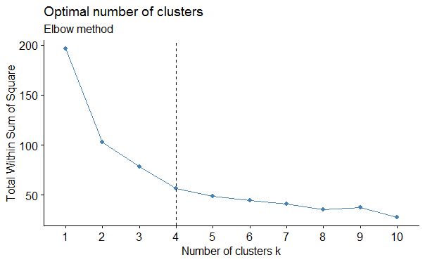

5. compute the k-means clustering with the suggested number of clusters

```
K-means clustering with 4 clusters of sizes 13, 16, 13, 8

Cluster means:
      Murder    Assault   UrbanPop        Rape
1 -0.9615407 -1.1066010 -0.9301069 -0.96676331
2 -0.4894375 -0.3826001  0.5758298 -0.26165379
3  0.6950701  1.0394414  0.7226370  1.27693964
4  1.4118898  0.8743346 -0.8145211  0.01927104

Clustering vector:
       Alabama         Alaska        Arizona       Arkansas     California       Colorado    Connecticut       Delaware        Florida        Georgia
             4              3              3              4              3              3              2              2              3              4
        Hawaii          Idaho       Illinois        Indiana           Iowa         Kansas       Kentucky      Louisiana          Maine       Maryland
             2              1              3              2              1              2              1              4              1              3
 Massachusetts       Michigan      Minnesota    Mississippi       Missouri        Montana       Nebraska         Nevada  New Hampshire     New Jersey
             2              3              1              4              3              1              1              3              1              2
    New Mexico       New York North Carolina   North Dakota           Ohio       Oklahoma         Oregon   Pennsylvania   Rhode Island South Carolina
             3              3              4              1              2              2              2              2              2              4
  South Dakota      Tennessee          Texas           Utah        Vermont       Virginia     Washington  West Virginia      Wisconsin        Wyoming
             1              4              3              2              1              2              2              1              1              2

Within cluster sum of squares by cluster:
[1] 11.952463 16.212213 19.922437  8.316061
 (between_SS / total_SS =  71.2 %)

Available components:

[1] "cluster"      "centers"      "totss"        "withinss"     "tot.withinss" "betweenss"    "size"         "iter"         "ifault"
```

6. Read the help of the function `fviz_cluster` in `factoextra` package and use it to plot the the result of th clustering.

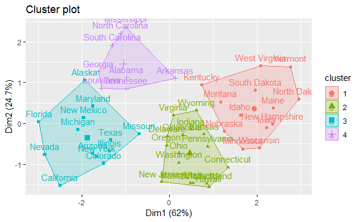

7. Select a random subest `df_small` (test data) from the `USArrests` and use `cl_predict` function from the `clue` package to assign these data to the corresponding clusters.

## DBSCAN

1. Load the `multishapes` data and make sure taht `fpc`;`dbscan` and `factoextra` are loaded.  
   Ecpect the data by plotting

[output not shown]

Apply the `kmeans` function to the `multishapes` data (the first two columns) and plot the results

2. The function `dbscan()` to clustwer the data and plot the results

Note that, the function `plot.dbscan()` uses different point symbols for core points (i.e, seed points) and border points. Black points correspond to outliers. You can play with eps and MinPts for changing cluster configurations.

3. Compare k-means and DBSCAN algorithms and conclude for this data set.
4. plot the result of the DBSCAN clustering using the `fviz_cluster` function from the `factoextra` package
5. print the results of `fpc::dbscan()`

Try to read the table

[output not shown]

6. Print the cluster membership using tje `$cluster` attribute

[output not shown]

The method proposed here consists of computing the he k-nearest neighbor distances in a matrix of points.

The idea is to calculate, the average of the distances of every point to its `k`-nearest neighbors. The value of `k` will be specified by the user and corresponds to MinPts.

Next, these k-distances are plotted in an ascending order. The aim is to determine the “knee”, which corresponds to the optimal eps parameter.

A knee corresponds to a threshold where a sharp change occurs along the k-distance curve.

The function kNNdistplot() [in dbscan package] can be used to draw the k-distance plot: